# POLI 178: Afghanistan Military Spending EDA

Baraa Zekeria

October 21, 2021

# Afghanistan: Military Expenditure as Share of GDP

- The effect of US intervention on Afghanistan’s military spending
- Military spending is intimately linked to war. In times of peace, few countries spend more than 5% of GDP on their military, choosing instead to maintain their capabilities and make use of their armies in other ways.

[Our World Data - Violence and War](https://ourworldindata.org/military-spending)

# Clear Environment

```r
rm(list=ls(all=TRUE))
```

# Load Package

```r
library(tidyverse)
```

# Load Data

```r
mil_exp <- read_csv("military-expenditure-as-share-of-gdp.csv")
```

# View Data

```r
glimpse(mil_exp)
```

```
## Rows: 9,680
## Columns: 4
## $ Entity  <chr> "Afghanistan", "Afghanistan", "Afghanistan", "Afghanistan", "A…
## $ Code    <chr> "AFG", "AFG", "AFG", "AFG", "AFG", "AFG", "AFG", "AFG", "AFG",…
## $ Year    <dbl> 1970, 1973, 1974, 1975, 1976, 1977, 2004, 2005, 2006, 2007, 20…
## $ pct_gdp <dbl> 1.6296061, 1.8689103, 1.6108247, 1.7220657, 2.0460870, 2.01147…
```

```r
colnames(mil_exp)
```

```
## [1] "Entity"  "Code"    "Year"    "pct_gdp"
```

# Change the **class()** of the `Year` and `pct_gdp` columns

```r
mil_exp$Year <- as.numeric(mil_exp$Year)
mil_exp$pct_gdp <- as.numeric(mil_exp$pct_gdp)
```

## Confirm the data type changes

```r
class(mil_exp$Year)
```

```
## [1] "numeric"
```

```r
class(mil_exp$pct_gdp)
```

```
## [1] "numeric"
```

## Drop the `code` column given its redundance for this analysis

```r
mil_exp <- subset(mil_exp, select = -c(Code))
```

### Confirm the drop by calling the **colnames()** function

```r
colnames(mil_exp)
```

```
## [1] "Entity"  "Year"    "pct_gdp"
```

## Subset the DF to only include where the `Entity` is `Afghanistan` and re-assign it to the `mil_exp` object

```r
mil_exp <- mil_exp %>%
  filter(Entity == "Afghanistan")
```

## Create a new column, `intervention_type`, given the `Year` values

```r
mil_exp$intervention_type <- ifelse(mil_exp$Year >= 2001, "Post-US Intervention", "Pre-US Intervention")
```

# Summary Statistics

## Since the focus of this project is related to US intervention of analysis starting in 2001, find the diifference in means for `pct_GDP`

```r
# Filter to 2 separate DF's
pre_us <- mil_exp %>%
  filter(Year < 2001)

post_us <- mil_exp %>%
  filter(Year >= 2001)
```

```r
# Calculate the means
avg_pct_gdp <- mean(mil_exp$pct_gdp)

pre_us_avg_pct_gdp <- mean(pre_us$pct_gdp)

post_us_avg_pct_gdp <- mean(post_us$pct_gdp)
```

- Means
  - Overall: 1.6632973%
  - Pre-US (< 2001): 1.8148281%
  - Post-US (>= 2001): 1.6064732%
  - Difference: 0.2083549%

# Visualization

## Show the trend in military expenditure post-US intervention

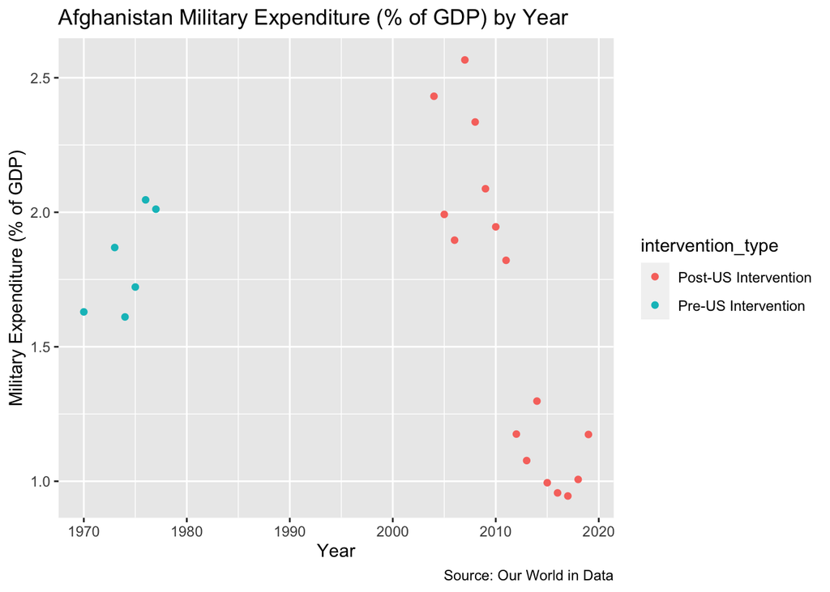

```r
ggplot(data = mil_exp,
       aes(x = Year,
           y = pct_gdp,
           color = intervention_type)) +
  geom_point() +
  labs(title = "Afghanistan Military Expenditure (% of GDP) by Year",
       x = "Year",
       y = "Military Expenditure (% of GDP)",
       caption = "Source: Our World in Data")
```

Before the US intervention on Afghanistan, we notice a roughly positive correlation in military spending from 1970-1977. The, from 2004-2009, during that 6 year period, we see an up and down trend with military spending. Though the data changes, come 2010, where military spending continuously decreases from ~ 1.9% - 1.1 %. We see a slight increase in 2014 and 2018, 1.08% to 1.30% and 0.95% to 1.01%, respectively.

*Note: Data was not taken into account from 1978-2003*